# Structural Equation Modeling | Lab Session 4

# 1 What we are going to cover

1. Non-normal continuous data
2. Categorical data
3. Missing data

# 2 Data

The data set used throughout is the European Social Survey ESS4-2008 Edition 4.5 was released on 1 December 2018. We will restrict the analysis to the Belgian case. Each line in the data set represents a Belgian respondent. The full dataset an documentation can be found on the [ESS website](https://www.europeansocialsurvey.org/data/download.html?r=4)

Codebook:

- **gvslvol** Standard of living for the old, governments’ responsibility (0 Not governments’ responsibility at all - 10 Entirely governments’ responsibility)
- **gvslvue** Standard of living for the unemployed, governments’ responsibility (0 Not governments’ responsibility at all - 10 Entirely governments’ responsibility)
- **gvhlthc** Health care for the sick, governments’ responsibility (0 Not governments’ responsibility at all - 10 Entirely governments’ responsibility)
- **gvcldcr** Child care services for working parents, governments’ responsibility (0 Not governments’ responsibility at all - 10 Entirely governments’ responsibility)
- **gvjbevn** Job for everyone, governments’ responsibility (0 Not governments’ responsibility at all - 10 Entirely governments’ responsibility)
- **gvpdlwk** Paid leave from work to care for sick family, governments’ responsibility (0 Not governments’ responsibility at all - 10 Entirely governments’ responsibility)
- **sbstrec** Social benefits/services place too great strain on economy (1 Agree strongly - 5 Disagree strongly)
- **sbbsntx** Social benefits/services cost businesses too much in taxes/charges (1 Agree strongly - 5 Disagree strongly)
- **sbprvpv** Social benefits/services prevent widespread poverty (1 Agree strongly - 5 Disagree strongly)
- **sbeqsoc** Social benefits/services lead to a more equal society (1 Agree strongly - 5 Disagree strongly)
- **sbcwkfm** Social benefits/services make it easier to combine work and family (1 Agree strongly - 5 Disagree strongly)
- **sblazy** Social benefits/services make people lazy (1 Agree strongly - 5 Disagree strongly)
- **sblwcoa** Social benefits/services make people less willing care for one another (1 Agree strongly - 5 Disagree strongly)
- **sblwlka** Social benefits/services make people less willing look after themselves/family (1 Agree strongly - 5 Disagree strongly)
- **agea** Respondent’s age
- **eduyrs** Years of full-time education completed
- **gndr** Gender (1 Male, 2 Female)
- **hinctnta** Household’s total net income, all sources (Deciles of the actual household income range in the given country.)
- **gincdif** Government should reduce differences in income levels (1 Agree strongly - 5 Disagree strongly)
- **dfincac** Large differences in income acceptable to reward talents and efforts (1 Agree strongly - 5 Disagree strongly)
- **smdfslv** For fair society, differences in standard of living should be small (1 Agree strongly - 5 Disagree strongly)

# 3 Environment preparation

First, let’s load the necessary packages to load, manipulate, visualize and analyse the data.

```r
# Uncomment this once if you need to install the packages on your system

### DATA MANIPULATION ###
# install.packages("haven")                 # data import from spss
# install.packages("dplyr")                 # data manipulation
# install.packages("psych")                 # descriptives
# install.packages("stringr")               # string manipulation
# install.packages("purrr")                 # table manipulation

### MODELING ###
# install.packages("lavaan")                # SEM modelling
# install.packages("MVN")                   # tests for multivariate normality
# install.packages("Amelia")                # performing multiple imputation

### VISUALIZATION ###
# install.packages("tidySEM")               # plotting SEM models
# install.packages("ggplot2")               # plotting
# install.packages("patchwork")             # organization plots

# Load the packages

### DATA MANIPULATION ###
library("haven")
library("dplyr")
library("psych")
library("stringr")
library("purrr")

### MODELING ###
library("lavaan")
library("MVN")
library("Amelia")

### VISUALIZATION ###
library("tidySEM")
library("ggplot2")
library("patchwork")
```

# 4 Non-normal, continuous data

Special data analytic techniques for non-normal continuous variables should be used if any of the continuous variables in the model are non-normal. maximum likelihood (ML) with non normal continuous variables results in biased standard errors and model fit deterioration. Practically, this means that that chi-square will be erroneously too large and standard errors are too small increasing the probability of TYpe-1 errors. The parameter estimates (e.g., loadings, regression coefficients) are largely unaffected (Finch, West, & MacKinnon, 1997).

## 4.1 Detecting non-normality

Unadjusted ML analysis approach most commonly employed for SEM assumes multivariate normality. One first step to assess multivariate normality consist in checking if the univariate distributions are normal. If the univariate distributions are non-normal, then the multivariate distribution will be non normal. We can plot the univariate distribution of our variables and perform a Kolmogorov-Smirnov test.

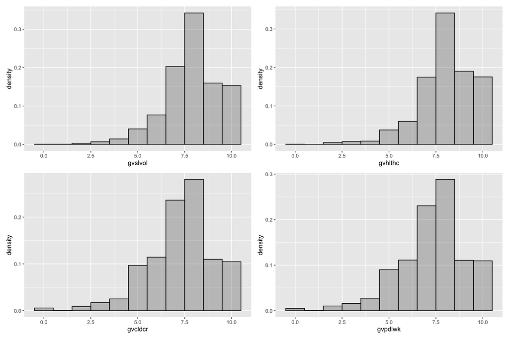

```r
ess_df <- haven::read_sav("https://github.com/albertostefanelli/SEM_labs/raw/master/ESS4_belgium.sav")

# We are going to measure welfare support using 4 items: gvslvol gvhlthc gvcldcr gvpdlwk
# First let's visually inspect our variables

h_gvslvol <- ggplot(ess_df, aes(gvslvol)) +
        geom_blank() +
        geom_histogram(aes(y = ..density..), binwidth = 1, colour = "black", alpha=0.3)

h_gvhlthc <- ggplot(ess_df, aes(gvhlthc)) +
        geom_blank() +
        geom_histogram(aes(y = ..density..), binwidth = 1, colour = "black", alpha=0.3)

h_gvcldcr <- ggplot(ess_df, aes(gvcldcr)) +
        geom_blank() +
        geom_histogram(aes(y = ..density..), binwidth = 1, colour = "black", alpha=0.3)

h_gvpdlwk <- ggplot(ess_df, aes(gvpdlwk)) +
        geom_blank() +
        geom_histogram(aes(y = ..density..), binwidth = 1, colour = "black", alpha=0.3)

h_gvslvol + h_gvhlthc + h_gvcldcr + h_gvpdlwk
```

We can check if a distribution is normal (or almost) using Kolmogorov-Smirnov (KS) test. The KS test returns a D statistic and a p-value corresponding to the D statistic. The D statistic is the absolute maximum distance between the cumulative distribution function of our variable and a randomly generated normally distributed variable with the same mean and standard deviation. The closer D is to 0 the more the distribution of our variable resemble a normal distribution.

```r
ks_gvslvol <- ks.test(ess_df$gvslvol, "pnorm", mean=mean(ess_df$gvslvol, na.rm=T), sd=sd(ess_df$gvslvol, na.rm=T))
ks_gvhlthc <- ks.test(ess_df$gvhlthc, "pnorm", mean=mean(ess_df$gvhlthc, na.rm=T), sd=sd(ess_df$gvhlthc, na.rm=T))
ks_gvcldcr <- ks.test(ess_df$gvcldcr, "pnorm", mean=mean(ess_df$gvcldcr, na.rm=T), sd=sd(ess_df$gvcldcr, na.rm=T))
ks_gvpdlwk <- ks.test(ess_df$gvpdlwk, "pnorm", mean=mean(ess_df$gvpdlwk, na.rm=T), sd=sd(ess_df$gvpdlwk, na.rm=T))

data.frame(Variables= c("gvslvol","gvhlthc","gvcldcr", "gvpdlwk"),
          D = round(c(ks_gvslvol$statistic, ks_gvhlthc$statistic, ks_gvcldcr$statistic, ks_gvpdlwk$statistic),2),
          "P-value" = c(ks_gvslvol$p.value, ks_gvhlthc$p.value, ks_gvcldcr$p.value, ks_gvpdlwk$p.value)
           )
```

```
  Variables    D P.value
1   gvslvol 0.19       0
2   gvhlthc 0.20       0
3   gvcldcr 0.17       0
4   gvpdlwk 0.17       0
```

We can also also have multivariate non normality even when all the individual variables are normally distributed (although severe multivariate non normality is probably less likely). There are different multivariate normality tests (i.e., Mardia, Royston, Doornik-Hansen), we are going to use the Henze-Zirkler’s multivariate normality test. For multivariate normality, the test p-value should be greater than 0.05

```r
# select the ws items
ess_df_ws <- ess_df[,c("gvslvol", "gvhlthc", "gvcldcr", "gvpdlwk")]
# remove NAs
ess_df_ws_na <- na.omit(ess_df_ws)

mvn_test <- mvn(data = ess_df_ws, # our data without NAs
                mvnTest = c("hz") # type of normality test to perform
                )

mvn_test$multivariateNormality
```

```
           Test       HZ p value MVN
1 Henze-Zirkler 27.21174       0  NO
```

To mitigate non-normality we can use scaled ${\chi^2}$ and “robust” standard errors corrections to ML estimation as in Satorra and Bentler (1988; 1994). Adjustments are made to the ${\chi^2}$ (and ${\chi^2}$ based fit indices) and standard errors based on a weight matrix derived from an estimate of multivariate kurtosis (as said before, the parameter estimates themselves are not altered).

```r
model_ws  <-'
ws =~   gvslvol + # Standard of living for the old
        gvhlthc + # Health care for the sick
        gvcldcr + # Child care services for working parents
        gvpdlwk   # Paid leave from work to care for sick family

'

fit_ws_ml <- cfa(model_ws,          # model formula
                  data = ess_df,    # data frame
                  estimator = "ML"  # select the estimator
)

fit_ws_mlr <- cfa(model_ws,          # model formula
                  data = ess_df,     # data frame
                  estimator = "MLM"  # select the estimator
)

summary(fit_ws_mlr,
        fit.measures=TRUE)
```

```
lavaan 0.6-7 ended normally after 23 iterations

  Estimator                                         ML
  Optimization method                           NLMINB
  Number of free parameters                          8

                                                  Used       Total
  Number of observations                          1745        1760

Model Test User Model:
                                              Standard      Robust
  Test Statistic                               266.283     106.210
  Degrees of freedom                                 2           2
  P-value (Chi-square)                           0.000       0.000
  Scaling correction factor                                  2.507
       Satorra-Bentler correction

Model Test Baseline Model:

  Test statistic                              1921.621    1147.034
  Degrees of freedom                                 6           6
  P-value                                        0.000       0.000
  Scaling correction factor                                  1.675

User Model versus Baseline Model:

  Comparative Fit Index (CFI)                    0.862       0.909
  Tucker-Lewis Index (TLI)                       0.586       0.726

  Robust Comparative Fit Index (CFI)                         0.863
  Robust Tucker-Lewis Index (TLI)                            0.590

Loglikelihood and Information Criteria:

  Loglikelihood user model (H0)             -12411.000  -12411.000
  Loglikelihood unrestricted model (H1)             NA          NA

  Akaike (AIC)                               24837.999   24837.999
  Bayesian (BIC)                             24881.715   24881.715
  Sample-size adjusted Bayesian (BIC)        24856.300   24856.300
```

[output cut: 22 more lines]

```
Latent Variables:
                   Estimate  Std.Err  z-value  P(>|z|)
  ws =~
    gvslvol           1.000
    gvhlthc           0.921    0.044   20.858    0.000
    gvcldcr           0.852    0.052   16.287    0.000
    gvpdlwk           0.876    0.051   17.080    0.000

Variances:
                   Estimate  Std.Err  z-value  P(>|z|)
   .gvslvol           0.846    0.080   10.619    0.000
   .gvhlthc           1.024    0.084   12.134    0.000
   .gvcldcr           2.126    0.134   15.832    0.000
   .gvpdlwk           2.055    0.138   14.915    0.000
    ws                1.350    0.103   13.124    0.000
```

# 5 Categorical data

1. binary: male/female, dead/alive
2. nominal with $K>2$: race (black, latino, asian)
3. ordinal: ses (high, middle, low), likert scales (agree strongly, agree, neutral, disagree, disagree strongly)
4. counts: number of deadly accidents in a year

Lavaan can deal only with binary and ordinal endogenous variables. There are two approaches to categorical variables in SEM. Only the three-stage WLS approach is well implemented in Lavaan and includes ‘robust’ variants (the other approach is called full information approach and the estimator is reffered to marginal maximum likelihood). Let’s use the social (sbprvpv, sbeqsoc, sbcwkfm) and moral (sblazy, sblwcoa, sblwlka) criticism items to estimate a model with two first-order ordered latent variables.

Stages of WLS:

1. An observed variable $y$ can be seen as a latent continuous variable $y^*$, in our social criticism example an ordinal variable with K = 5 response categories. The model estimates thresholds using univariate information only. This is part of the mean structure of the model.
2. Keeping the thresholds fixed, the model estimates the correlations. Only the correlation matrix is used, rather than covariance matrix. In our example with ordinal data, the model estimates polychoric correlations.
3. The full SEM model is estimated using weighted least squares. If exogenous covariates are involved (i.e. regression paths), the correlations are adjusted on based on the values of $y^*$. Residual variances of $y^*$ is estimated (called “scale parameters”)

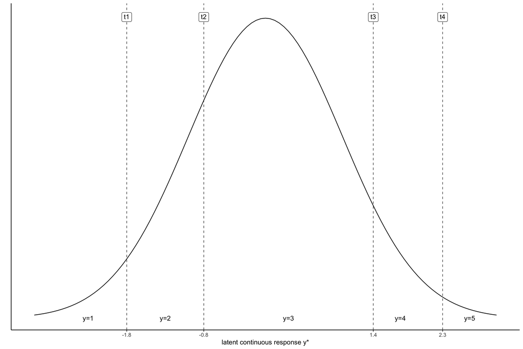

```r
model_wc <-'
## Social criticism ##
wc_socia =~ sbprvpv + sbeqsoc + sbcwkfm
##  Moral criticism ##
wc_moral =~ sblazy + sblwcoa + sblwlka
'

fit_wc_wlsmv <- cfa(model_wc,
                    ordered = c("sbprvpv",
                                "sbeqsoc",
                                "sbcwkfm",
                                "sblazy",
                                "sblwcoa",
                                "sblwlka" ),
                    data = ess_df,
                    estimator = "WLSMV"
)
summary(fit_wc_wlsmv)
```

```
lavaan 0.6-7 ended normally after 23 iterations

  Estimator                                       DWLS
  Optimization method                           NLMINB
  Number of free parameters                         31

                                                  Used       Total
  Number of observations                          1711        1760

Model Test User Model:
                                              Standard      Robust
  Test Statistic                                21.993      29.388
  Degrees of freedom                                 8           8
  P-value (Chi-square)                           0.005       0.000
  Scaling correction factor                                  0.783
  Shift parameter                                            1.287
       simple second-order correction

Parameter Estimates:

  Standard errors                           Robust.sem
  Information                                 Expected
  Information saturated (h1) model        Unstructured

Latent Variables:
                   Estimate  Std.Err  z-value  P(>|z|)
  wc_socia =~
    sbprvpv           1.000
    sbeqsoc           1.443    0.120   11.979    0.000
    sbcwkfm           0.691    0.044   15.740    0.000
  wc_moral =~
    sblazy            1.000
    sblwcoa           1.132    0.027   42.700    0.000
    sblwlka           1.015    0.024   42.012    0.000

Covariances:
                   Estimate  Std.Err  z-value  P(>|z|)
  wc_socia ~~
    wc_moral         -0.041    0.014   -2.890    0.004

```

[output cut: 42 more lines]

```
   .sbcwkfm           0.822
   .sblazy            0.459
   .sblwcoa           0.306
   .sblwlka           0.442
    wc_socia          0.372    0.036   10.462    0.000
    wc_moral          0.541    0.020   27.352    0.000

Scales y*:
                   Estimate  Std.Err  z-value  P(>|z|)
    sbprvpv           1.000
    sbeqsoc           1.000
    sbcwkfm           1.000
    sblazy            1.000
    sblwcoa           1.000
    sblwlka           1.000
```

# 6 Missing data

Different types of missingness:

1. Missing completely at random (MCAR) if the events that lead to any particular data-item being missing are independent both of observable variables and of unobservable parameters of interest, and occur entirely at random. When data are MCAR, the analyses performed on the data are unbiased; however, data are rarely MCAR.
2. Missing at random (MAR) occurs when the missingness is not random, but where missingness can be fully accounted for by variables on which there is complete information. MAR is an assumption that is impossible to verify statistically, we must rely on its substantive reasonableness.
3. Missing not at random (MNAR) (also known as nonignorable nonresponse) is data that is neither MAR nor MCAR (i.e. the value of the variable that’s missing is related to the reason it’s missing).

Three different approaches to missing data (See Brown, Chapter 9)

1. Default behaviour: listwise deletion
2. Best option: Case-wise (or ‘full information’) maximum likelihood (FIML). Can be employed ONLY when the missing mechanism is MCAR or MAR. A scaled (‘Yuan-Bentler’) test statistic similar to the one used for non-normal continuous data can be computed.
3. Second best option: Multiple imputation

```r
model_wc <-'
## Economic criticism ##
wc_econo =~ sbstrec + sbbsntx
## Social criticism ##
wc_socia =~ sbprvpv + sbeqsoc + sbcwkfm
##  Moral criticism ##
wc_moral =~ sblazy + sblwcoa + sblwlka
'

# listwise

fit_wc_6_listwise <- cfa(model_wc,               # model formula
                        data = ess_df,           # data frame
                        missing = "listwise"     # listwise
  )

summary(fit_wc_6_listwise)
```

```
lavaan 0.6-7 ended normally after 36 iterations

  Estimator                                         ML
  Optimization method                           NLMINB
  Number of free parameters                         19

                                                  Used       Total
  Number of observations                          1679        1760

Model Test User Model:

  Test statistic                                71.348
  Degrees of freedom                                17
  P-value (Chi-square)                           0.000

Parameter Estimates:

  Standard errors                             Standard
  Information                                 Expected
  Information saturated (h1) model          Structured

Latent Variables:
                   Estimate  Std.Err  z-value  P(>|z|)
  wc_econo =~
    sbstrec           1.000
    sbbsntx           1.001    0.093   10.817    0.000
  wc_socia =~
    sbprvpv           1.000
    sbeqsoc           1.493    0.166    9.011    0.000
    sbcwkfm           0.631    0.055   11.461    0.000
  wc_moral =~
    sblazy            1.000
    sblwcoa           1.058    0.045   23.285    0.000
    sblwlka           0.977    0.043   22.843    0.000

Covariances:
                   Estimate  Std.Err  z-value  P(>|z|)
  wc_econo ~~
    wc_socia         -0.024    0.011   -2.093    0.036
    wc_moral          0.250    0.023   10.872    0.000
  wc_socia ~~
    wc_moral         -0.034    0.012   -2.915    0.004

Variances:
                   Estimate  Std.Err  z-value  P(>|z|)
   .sbstrec           0.647    0.042   15.381    0.000
   .sbbsntx           0.603    0.041   14.584    0.000
   .sbprvpv           0.554    0.030   18.722    0.000
   .sbeqsoc           0.224    0.051    4.404    0.000
   .sbcwkfm           0.518    0.020   25.832    0.000
   .sblazy            0.551    0.027   20.083    0.000
   .sblwcoa           0.441    0.027   16.639    0.000
   .sblwlka           0.539    0.027   20.320    0.000
    wc_econo          0.395    0.045    8.689    0.000
    wc_socia          0.213    0.029    7.328    0.000
    wc_moral          0.561    0.039   14.477    0.000
```

```r
#Full information  maximum likelihood (FIML)

fit_wc_6_fiml <- cfa(model_wc,                # model formula
                     data = ess_df,           # data frame
                     missing = "direct"       # alias: "ml" or "fiml"
  )

summary(fit_wc_6_fiml)
```

```
lavaan 0.6-7 ended normally after 45 iterations

  Estimator                                         ML
  Optimization method                           NLMINB
  Number of free parameters                         27

                                                  Used       Total
  Number of observations                          1758        1760
  Number of missing patterns                        34

Model Test User Model:

  Test statistic                                75.087
  Degrees of freedom                                17
  P-value (Chi-square)                           0.000

Parameter Estimates:

  Standard errors                             Standard
  Information                                 Observed
  Observed information based on                Hessian

Latent Variables:
                   Estimate  Std.Err  z-value  P(>|z|)
  wc_econo =~
    sbstrec           1.000
    sbbsntx           1.011    0.092   10.931    0.000
  wc_socia =~
    sbprvpv           1.000
    sbeqsoc           1.420    0.172    8.270    0.000
    sbcwkfm           0.627    0.053   11.752    0.000
  wc_moral =~
    sblazy            1.000
    sblwcoa           1.065    0.045   23.481    0.000
    sblwlka           0.977    0.043   22.799    0.000

Covariances:
                   Estimate  Std.Err  z-value  P(>|z|)
  wc_econo ~~
    wc_socia         -0.019    0.012   -1.592    0.111
```

[output cut: 16 more lines]

```
    wc_moral          0.000

Variances:
                   Estimate  Std.Err  z-value  P(>|z|)
   .sbstrec           0.652    0.041   15.866    0.000
   .sbbsntx           0.598    0.041   14.681    0.000
   .sbprvpv           0.537    0.032   16.919    0.000
   .sbeqsoc           0.246    0.053    4.611    0.000
   .sbcwkfm           0.516    0.020   25.386    0.000
   .sblazy            0.556    0.027   20.343    0.000
   .sblwcoa           0.438    0.026   16.852    0.000
   .sblwlka           0.538    0.026   20.842    0.000
    wc_econo          0.387    0.044    8.737    0.000
    wc_socia          0.223    0.032    7.019    0.000
    wc_moral          0.558    0.038   14.626    0.000
```

```r
# combine both robust standard errors (sandwich) and a scaled test statistic (Satorra Bentler)

fit_wc_6_fiml_mr <- cfa(model_wc,                # model formula
                     data = ess_df,              # data frame
                     missing = "direct",         # alias: "ml" or "fiml"
                     estimator = "MLR"           # Estimator: ML Robust
  )

summary(fit_wc_6_fiml_mr,
        fit.measures=TRUE)
```

```
lavaan 0.6-7 ended normally after 45 iterations

  Estimator                                         ML
  Optimization method                           NLMINB
  Number of free parameters                         27

                                                  Used       Total
  Number of observations                          1758        1760
  Number of missing patterns                        34

Model Test User Model:
                                               Standard      Robust
  Test Statistic                                 75.087      66.620
  Degrees of freedom                                 17          17
  P-value (Chi-square)                            0.000       0.000
  Scaling correction factor                                   1.127
       Yuan-Bentler correction (Mplus variant)

Model Test Baseline Model:

  Test statistic                              2508.464    1964.310
  Degrees of freedom                                28          28
  P-value                                        0.000       0.000
  Scaling correction factor                                  1.277

User Model versus Baseline Model:

  Comparative Fit Index (CFI)                    0.977       0.974
  Tucker-Lewis Index (TLI)                       0.961       0.958

  Robust Comparative Fit Index (CFI)                         0.977
  Robust Tucker-Lewis Index (TLI)                            0.963

Loglikelihood and Information Criteria:

  Loglikelihood user model (H0)             -17781.687  -17781.687
  Scaling correction factor                                  1.163
      for the MLR correction
  Loglikelihood unrestricted model (H1)             NA          NA
  Scaling correction factor                                  1.149
```

[output cut: 61 more lines]

```
    wc_moral          0.000

Variances:
                   Estimate  Std.Err  z-value  P(>|z|)
   .sbstrec           0.652    0.048   13.681    0.000
   .sbbsntx           0.598    0.044   13.742    0.000
   .sbprvpv           0.537    0.044   12.185    0.000
   .sbeqsoc           0.246    0.078    3.151    0.002
   .sbcwkfm           0.516    0.026   19.909    0.000
   .sblazy            0.556    0.032   17.227    0.000
   .sblwcoa           0.438    0.031   14.278    0.000
   .sblwlka           0.538    0.032   17.058    0.000
    wc_econo          0.387    0.048    8.093    0.000
    wc_socia          0.223    0.045    4.934    0.000
    wc_moral          0.558    0.038   14.865    0.000
```

## 6.1 Imputing missing data

The third option is to perform multiple imputation of the missing data on our data. We can use the r package Amelia to perform multiple imputations. Amelia creates a bootstrapped version of the original data and then imputes the missing values of the original data. This involves imputing m values for each missing cell in your data matrix and creating m “completed” data sets. Across these different data sets, the observed values are the same, but the missing values are filled in with different imputations that reflect our uncertainty about the missing data.

```r
# select the welfare criticism items
ess_df_wc <- ess_df %>% select(sbstrec, sbbsntx, sbprvpv, sbeqsoc, sbcwkfm, sblazy, sblwcoa, sblwlka)
# Amelia explicitly requires a object of data.frame class
ess_df_wc <- data.frame(ess_df_wc)

a.out <- amelia(ess_df_wc,  # original dataset with missing
                m = 15,     # number of m "completed" data sets
                seed = 23   # set the seed
                )
```

[output not shown]

```r
summary(a.out)
```

```
Amelia output with 15 imputed datasets.
Return code:  1
Message:  Normal EM convergence.

Chain Lengths:
--------------
Imputation 1:  3
Imputation 2:  3
Imputation 3:  3
Imputation 4:  3
Imputation 5:  3
Imputation 6:  3
Imputation 7:  3
Imputation 8:  3
Imputation 9:  3
Imputation 10:  3
Imputation 11:  3
Imputation 12:  3
Imputation 13:  3
Imputation 14:  3
Imputation 15:  3

Rows after Listwise Deletion:  1679
Rows after Imputation:  1758
Patterns of missingness in the data:  35

Fraction Missing for original variables:
-----------------------------------------

        Fraction Missing
sbstrec      0.014204545
sbbsntx      0.026136364
sbprvpv      0.011363636
sbeqsoc      0.006818182
sbcwkfm      0.014204545
sblazy       0.005113636
sblwcoa      0.005113636
sblwlka      0.007954545
```

```r
# we can check each "completed" dataset against our original data
cbind(ess_df_wc$sbstrec, a.out$imputations$imp1$sbstrec)[c(75:85),]
```

```
      [,1]     [,2]
 [1,]    4 4.000000
 [2,]    4 4.000000
 [3,]    2 2.000000
 [4,]    2 2.000000
 [5,]    3 3.000000
 [6,]   NA 3.730925
 [7,]    2 2.000000
 [8,]    4 4.000000
 [9,]   NA 3.725792
[10,]   NA 3.527227
[11,]    3 3.000000
```

```r
# we need to use semTools to fit a lavaan model to multiple imputed data eets

out.mi <- semTools::runMI(
              model = model_wc,         # model
              data = a.out$imputations, # list of imputed data sets
              fun = "cfa",              # lavaan function
              estimator = "MLR"         # estimator
              )


summary(out.mi,
        fit.measures=TRUE)
```

[output not shown]

```
Parameter Estimates:

  Standard errors                             Sandwich
  Information bread                           Observed
  Observed information based on                Hessian

Latent Variables:
                   Estimate  Std.Err  t-value       df  P(>|t|)
  wc_econo =~
    sbstrec           1.000
    sbbsntx           1.008    0.100   10.114      Inf    0.000
  wc_socia =~
    sbprvpv           1.000
    sbeqsoc           1.425    0.256    5.575      Inf    0.000
    sbcwkfm           0.628    0.063    9.908      Inf    0.000
  wc_moral =~
    sblazy            1.000
    sblwcoa           1.067    0.046   23.293      Inf    0.000
    sblwlka           0.978    0.046   21.119      Inf    0.000

Covariances:
                   Estimate  Std.Err  t-value       df  P(>|t|)
  wc_econo ~~
    wc_socia         -0.019    0.017   -1.151      Inf    0.250
    wc_moral          0.251    0.025   10.031      Inf    0.000
  wc_socia ~~
    wc_moral         -0.034    0.013   -2.620      Inf    0.009

Variances:
                   Estimate  Std.Err  t-value       df  P(>|t|)
   .sbstrec           0.652    0.047   13.746 9222.880    0.000
   .sbbsntx           0.601    0.043   13.875      Inf    0.000
   .sbprvpv           0.538    0.044   12.187      Inf    0.000
   .sbeqsoc           0.244    0.079    3.087      Inf    0.002
   .sbcwkfm           0.518    0.026   19.865      Inf    0.000
   .sblazy            0.555    0.032   17.190      Inf    0.000
   .sblwcoa           0.438    0.031   14.217      Inf    0.000
   .sblwlka           0.538    0.032   17.083      Inf    0.000
    wc_econo          0.388    0.048    8.156      Inf    0.000
    wc_socia          0.223    0.045    4.915      Inf    0.000
    wc_moral          0.557    0.038   14.791      Inf    0.000
```

```r
# let's compare the fit of the different models
model_fit <-  function(lavobject) {
  vars <- c("chisq", "df", "cfi", "tli", "rmsea", "rmsea.ci.lower", "rmsea.ci.upper", "rmsea.pvalue", "srmr")
  return(fitmeasures(lavobject)[vars] %>% data.frame() %>% round(2) %>% t())
}

table_fit <-
  list(model_fit(fit_wc_6_listwise),
       model_fit(fit_wc_6_fiml),
       model_fit(out.mi)) %>%
  reduce(rbind)


rownames(table_fit) <- c("Listwise", "FIML", "Amelia")

table_fit
```

```
         chisq df  cfi  tli rmsea rmsea.ci.lower rmsea.ci.upper rmsea.pvalue srmr
Listwise 71.35 17 0.98 0.96  0.04           0.03           0.05         0.83 0.03
FIML     75.09 17 0.98 0.96  0.04           0.03           0.05         0.82 0.03
Amelia   75.07 17 0.98 0.96  0.04           0.03           0.05         0.82 0.03
```

*Q:* The fit statistics are similar across the models? Why?

Notes:

1. Binary variables: you can specify the nominals option in Amelia function
2. Ordinal variables: “Users are advised to allow Amelia to impute non-integer values for any missing data, and to use these non-integer values in their analysis. Sometimes this makes sense, and sometimes this defies intuition.”
3. Variables to include in the imputation model: “When performing multiple imputation, the first step is to identify the variables to include in the imputation model. It is crucial to include at least as much information as will be used in the analysis model. That is, any variable that will be in the analysis model should also be in the imputation model. This includes any transformations or interactions of variables that will appear in the analysis model.”
[^1]: [Alberto Stefanelli](https://albertostefanelli.com/)
[^2]: [Ahu Alanya](https://www.kuleuven.be/wieiswie/en/person/00081320)
[^3]: [Bart Meuleman](https://www.kuleuven.be/wieiswie/en/person/00041613)